# Climate Change Analysis

By:Slavoljub Petkovic

Jun, 2017

# 1 Introduction

In the past 4.5 billion years, Earth has gone through numerous climate changes that reshaped its surface and ecosystem, causing extinction and evolution itself. While the Sun is the biggest influence on our climate, the composition of Earth’s atmospheric gasses defines how much of the Sun’s energy will be trapped under the atmosphere. Ultimately the principles of thermodynamics while increasing the entropy, will govern the future of the Earth. Infinitesimal changes within a system in the present can cause changes within system in the future with a tremendous magnitude leaving the system incomparable to its primal state.

In this study, I will focus on a few questions related to current climate changes. For the research, I will be using the Data set published on Kaggle.com which contains data with temperature details in the period between 1750 and 2013:

[Data Location:] (https://www.kaggle.com/berkeleyearth/climate-change-earth-surface-temperature-data)

Questions of Interest:

1. What is the measurement problem and uncertainty level within these data sets?
2. What is the difference between the land and ocean average temperatures over time?
3. How do temperature extremes relate to average temperature?
4. What is the temperature trend over all the states/countries in the world?
5. What are the top 10 coldest and hottest major cities in the world?
6. What are the locations of the coldest vs. hottest major cities?
7. How does the average temperature difference look on a global scale?
8. What is the temperature trend for a city of residence (Atlanta)?
9. What kind of climate can we expect for the next 5 years, 10 years, 50 years and 100 years based on Predictive Analysis?
10. Is there active global warming?

# 2 Descriptive Analytics

## 2.1 Temperature Uncertanity for Data used in Descriptive Analytics

With given sets of data, we have a level of uncertainty due to imperfections in measurements and collection of the average temperature. Based on graph below we can see that between 1850 and 1975 we have a decline of uncertainty from 1.5% below 0.5%. The reliability of data stabilizes from 1975 with the exception to two outliers in 2013.

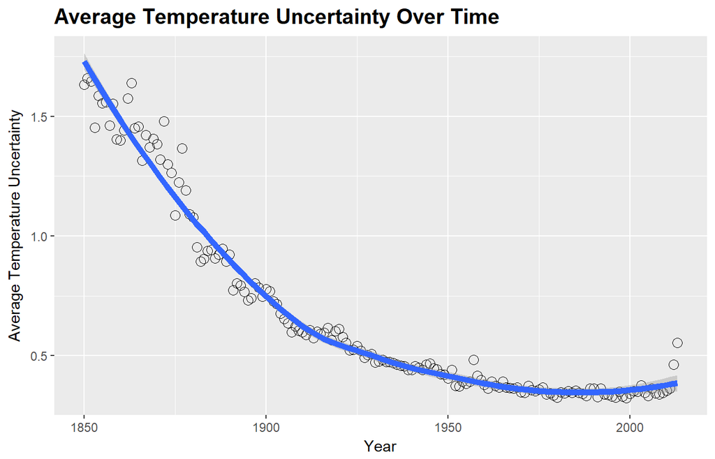

```r
# loading data set to explore data uncertainty. Eliminating NA values, standardizing dates and creating data sets for analysis.

TempByAllCities <- read_csv("C:/GIT/R/Data_Source/GlobalLandTemperaturesByCity.csv")
# Eliminating NAs
TempByAllCities <- na.omit(TempByAllCities)
# Converting dt to correct dates
TempByAllCities$dt <- as.Date(TempByAllCities$dt, "%Y-%m-%d")
# Filtering data range
TempByAllCities <- filter(TempByAllCities, dt>= "1849-12-31")
# Extracting the month out of dt
TempByAllCities$Month <- month(TempByAllCities$dt)
# Converting Month number to Month Name
TempByAllCities$Month <- month(TempByAllCities$Month, label = TRUE)
# Extracting the year out of dt
TempByAllCities$Year <- year(TempByAllCities$dt)
# Converting Lat and Long to correct format
TempByAllCities$LAT <- as.numeric(gsub("N|E|S|W", "",TempByAllCities$Latitude))*ifelse(grepl("S",TempByAllCities$Latitude),-1,1)
TempByAllCities$LONG <- as.numeric(gsub("N|E|S|W", "", TempByAllCities$Longitude))*ifelse(grepl("W",TempByAllCities$Longitude),-1,1)
AvgTempUncert <- TempByAllCities %>% group_by(Year) %>% summarise(AvgTempUnc = mean(AverageTemperatureUncertainty))
ggplot(AvgTempUncert,aes(x= Year,y= AvgTempUncert$AvgTempUnc))+
     geom_point(shape=1, size = 3)+ geom_smooth(method="loess", size = 2)+ labs(title="Average Temperature Uncertainty Over Time", x="Year", y="Average Temperature Uncertainty") + theme(plot.title = element_text(size = 15, lineheight=.8, face="bold"))
```

## 2.2 Exploring Seasons

Using the temperature data set from every city, we are going to explore the seasonality trend for the years between 1850 and 2013. On the Seasonality graph below we can see the average temperature increase over the century and half.

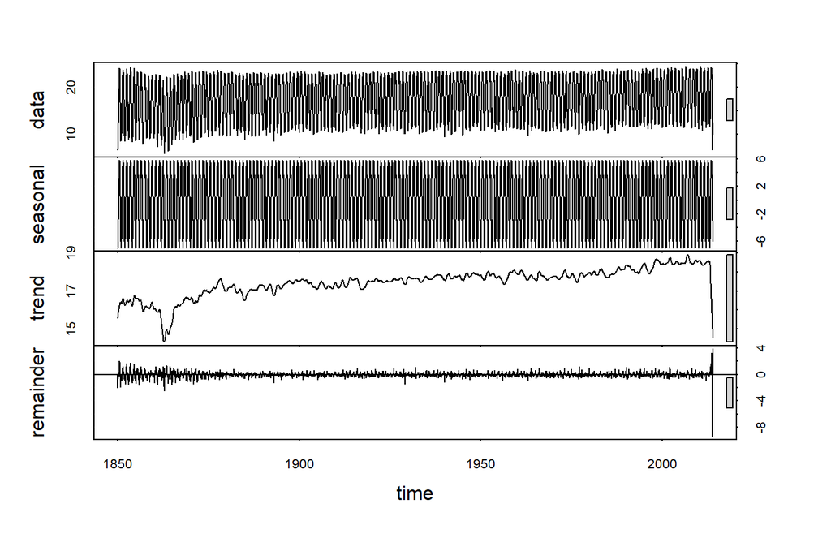

## 2.3 Analysis of Global Temperature (Land Vs Ocean)

ased on the Average Temperature Graph bellow, we can see that the average temperature of the land has been significantly increasing with a higher rate than the temperature of the ocean. Oceans are heating and cooling much faster than land due to the low density of the water. There are a few factors that could cause the average land temperature to increase with a higher rate than the ocean average temperature. With rapid deforestation, we reduce absorption of greenhouse gases that fuel global warming. Fewer forests will allow larger amounts of greenhouse gases to enter the atmosphere (~15% carbon) and trap the solar rays and heat up the surface that had once been protected by forest. Industrial effects within developed and developing countries plays a significant role where emission of greenhouse gasses (CO and CO2) directly influences speed and severity of the temperature in those regions and globally as well. The United States constitutes 5% of the world population and contributes 22% of the world’s carbon emission.

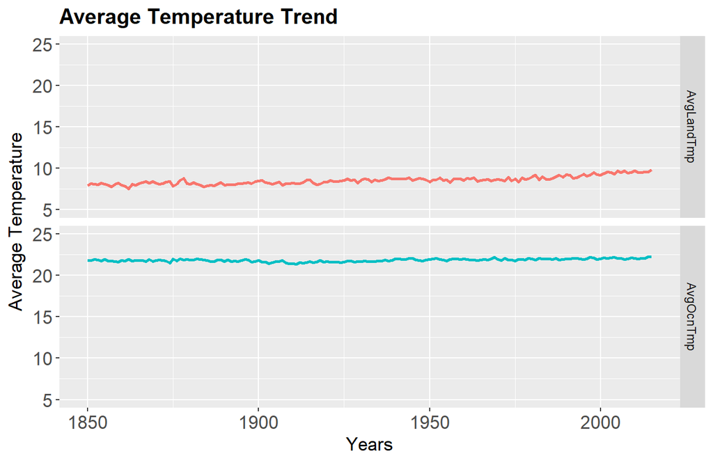

```r
# Loading data set
GlobalTemperatures <- read_csv("C:/GIT/R/Data_Source/GlobalTemperatures.csv")
# Standardizing the date format
GlobalTemperatures$dt = as.Date(GlobalTemperatures$dt, "%Y-%m-%d" )
# Filtering data range
GlobalTemperatures <- filter(GlobalTemperatures, dt>= "1849-12-31")
# Extracting the month out of the dt column in to new Monthviw column
GlobalTemperatures$Month <- month(GlobalTemperatures$dt)
# Converting month number in to Month Name
GlobalTemperatures$Month <- month(GlobalTemperatures$Month, label = TRUE)
# Extracting the year out of the dt column in to new Year column
GlobalTemperatures$Year <- year(GlobalTemperatures$dt)
# Remove rows that contains NA
GlobalTemperatures <- GlobalTemperatures[!is.na(GlobalTemperatures$LandAndOceanAverageTemperature)  | !is.na(GlobalTemperatures$LandAverageTemperature),]
# Calculate AverageOcean Temperature
GlobalTemperatures$OceanAverageTemperature = as.numeric(GlobalTemperatures$LandAndOceanAverageTemperature) * 2 - as.numeric(GlobalTemperatures$LandAverageTemperature)
# Summerizing temperature on yearly level
GlobalTemperaturesSummary <- GlobalTemperatures %>% group_by(Year) %>% summarise(AvgLandTmp = mean(LandAverageTemperature), AvgOcnTmp = mean(OceanAverageTemperature))
# Ploting Avgerage Ocean Temperature and Average Land temperature on timescale
Plot_ds <-melt(GlobalTemperaturesSummary, id ="Year")
ggplot(data= Plot_ds, aes(x=Year, y= value, colour = variable)) +
       geom_line(size = 1) + coord_cartesian(ylim = c(5, 25)) + xlab("Years") + ylab("Average Temperature") +
       theme(axis.title = element_text(size = 13), axis.text = element_text(size = 13)) +
       ggtitle("Average Temperature Trend") +
       theme(plot.title = element_text(size = 15, lineheight=.8, face="bold")) + facet_grid(Plot_ds$variable ~., scales = "free_y") + theme(legend.position="none")
```

## 2.4 Minimum and Maximum Average Temperature Trends

Analysis of temperature extremes over time require daily maximum and minimum temperature data from stations with records of sufficient length, quality, completeness, and temporal homogeneity. Homogeneity of the daily temperature record is a challenge due to stations experiencing variation in degrees of change over time for particular locations, instrumentation, observing practices, and sitting conditions. On the Min and Max Average Temperature Trend graph below, we can see the amplitudes of change for these extremes. It is clear that both temperature extremes across a century and a half are slightly increasing. the correlation between these extremes is ~90%.

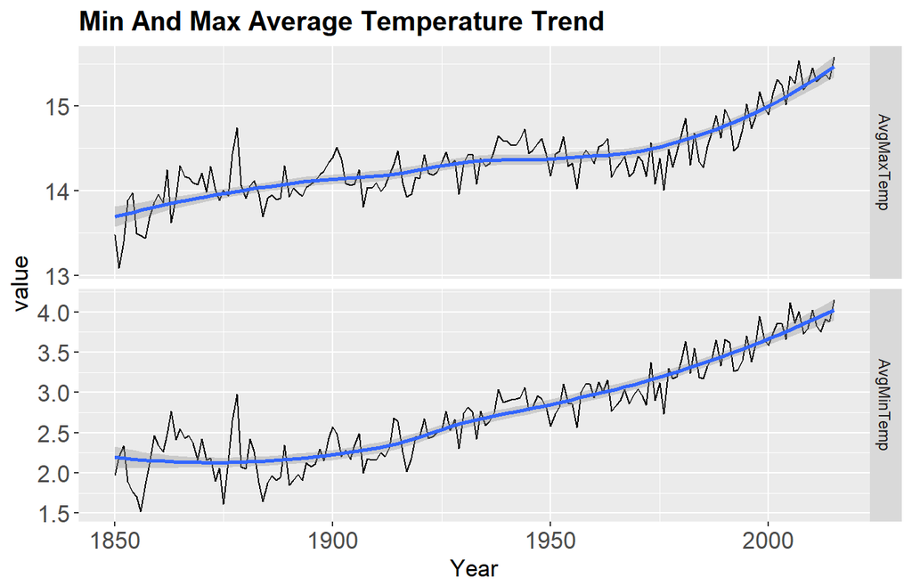

```r
# Extracting min and max values
GlobalTemperaturesMinMax <- GlobalTemperatures %>% group_by(Year) %>% summarise(AvgMaxTemp = mean(as.numeric(LandMaxTemperature)), AvgMinTemp = mean(as.numeric(LandMinTemperature)))
# Preparing variable for plot using melt function creating identifier and measured variable.
Plot_minMAx <-melt(GlobalTemperaturesMinMax, id = "Year")
# Plotting min and max temperature trend.
ggplot(data = Plot_minMAx, aes(Year, value, variable)) + geom_line(size = .5) + geom_smooth(size = 1) + facet_grid(Plot_minMAx$variable ~ ., scales = "free_y") + theme(axis.title = element_text(size = 13), axis.text = element_text(size = 13)) +
       ggtitle("Min And Max Average Temperature Trend") +
       theme(plot.title = element_text(size = 15, lineheight=.8, face="bold"))
```

```r
# Runing the coorelation between max and min temperature
cor(GlobalTemperaturesMinMax$AvgMaxTemp, GlobalTemperaturesMinMax$AvgMinTemp)
```

```
## [1] 0.8980115
```

## 2.5 Average Temperature Difference Between 1850 and 2013

The All State Average Temperature trend bellow illustrates the change in global surface temperature relative to 1850-2013 average temperatures. Thirteen of the warmest years in the 163-year record all have occurred since 2000. With a focus on the period between 1975 and 2013 the data shows nearly a 1-degree Celsius increase with respect to data uncertainty.

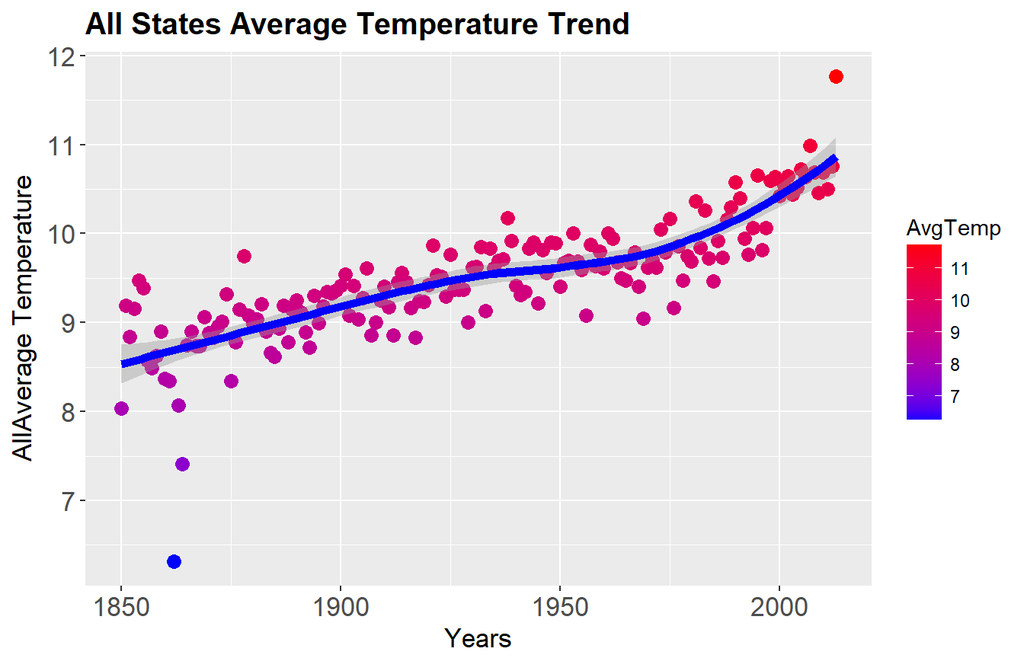

```r
# Loading data set
GlobalLandTemperaturesByState <- read_csv("C:/GIT/R/Data_Source/GlobalLandTemperaturesByState.csv")
# Formating dates
GlobalLandTemperaturesByState$dt <- as.Date(GlobalLandTemperaturesByState$dt, "%Y-%m-%d")
# Filtering data range
GlobalLandTemperaturesByState <- filter(GlobalLandTemperaturesByState, dt>= "1849-12-31")
#  Removing NAs
GlobalLandTemperaturesByState = na.omit(GlobalLandTemperaturesByState)
# Extracting Month from dt column in to new  Month column
GlobalLandTemperaturesByState$Month <- month(GlobalLandTemperaturesByState$dt)
GlobalLandTemperaturesByState$Year <- year(GlobalLandTemperaturesByState$dt)
# Extract avg temperature by year
GlobalTempSummary <- GlobalLandTemperaturesByState %>% group_by(Year) %>% summarise(AvgTemp = mean(AverageTemperature))
# Creating plot
ggplot(data = GlobalTempSummary, aes(x = Year, y = AvgTemp, colour = AvgTemp)) + geom_point(shape=16, size =3) + geom_smooth(method = 'loess', color = 'blue', size = 2) + xlab("Years") + ylab("AllAverage Temperature") + theme(axis.title = element_text(size = 13), axis.text = element_text(size = 13)) + ggtitle("All States Average Temperature Trend") + theme(plot.title = element_text(size = 15, lineheight=.8, face="bold")) + aes(Colour = AvgTemp) + scale_color_gradient(low = "blue", high = "red")
```

## 2.6 Top 10 Coldest Major Cities between 1850 - 2013

With the given average temperature for every major city, the bar chart below has the top 10 coldest cities in the world with descending rank.

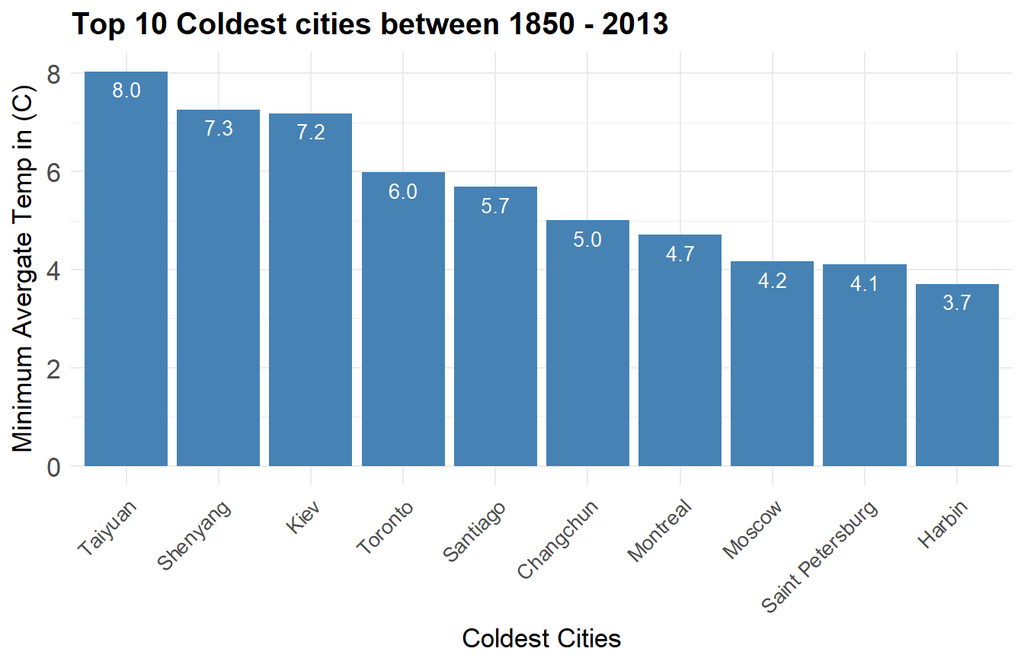

```r
# Loading data set
GlTempCity <- read_csv("C:/GIT/R/Data_Source/GlobalLandTemperaturesByMajorCity.csv")
#Formating Data Range
GlTempCity$dt <- as.Date(GlTempCity$dt, "%Y-%m-%d")
# Filtering data range
GlTempCity <- filter(GlTempCity, dt>= "1849-12-31")
# Filtering out NAs
GlTempCity = na.omit(GlTempCity)
# Extracting the month out of dt
GlTempCity$Month <- month(GlTempCity$dt)
# Converting Month number to Month Name
GlTempCity$Month <- month(GlTempCity$Month, label = TRUE)
# Extracting the year out of dt
GlTempCity$Year <- year(GlTempCity$dt)
# Grouping by City with avg. temperature on average
GlTempSum <- GlTempCity %>% group_by(City, Longitude, Latitude) %>% summarise(AvgTemp = mean(AverageTemperature))
# Extracting top 10 hotest city
Top10Hotest <- head(arrange(GlTempSum, desc(AvgTemp)), n= 10)
# Extracting top 10 coldest city on average
Top10Coldest <- head(arrange(GlTempSum, AvgTemp), n = 10)
# Plotting the the top 10 coldest cities
ggplot(data = Top10Coldest, aes(x = reorder(City, - AvgTemp), y = AvgTemp)) + geom_bar(stat = "identity", position = "dodge", fill="steelblue") + geom_text(aes(label=format(Top10Coldest$AvgTemp, digits = 2)), vjust=1.6, color="white", size=3.5) + theme_minimal() + xlab("Coldest Cities") + ylab("Minimum Avergate Temp in (C)") + theme(axis.title = element_text(size = 13), axis.text = element_text(size = 13)) + ggtitle("Top 10 Coldest cities between 1850 - 2013") + theme(plot.title = element_text(size = 15, lineheight=.8, face="bold")) + theme(axis.text.x = element_text(size  = 10, angle = 45, hjust = 1, vjust = 1))
```

## 2.7 Top 10 Hottest Major Cities between 1850 - 2013

While we have a drastic difference within the top 10 coldest major cities in the world, the top 10 hottest cities are very similar in comparison in their average temperature across a century and half.

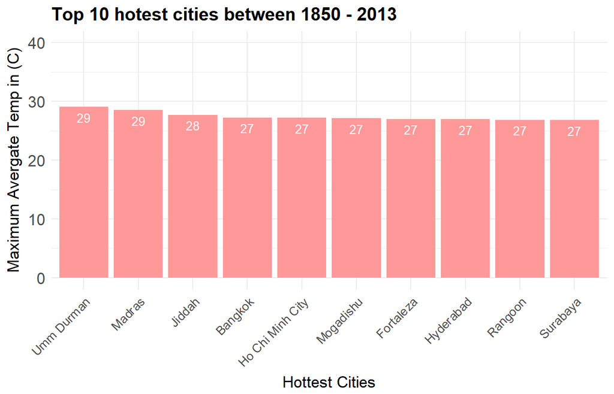

```r
# Plotting the top 10 hottest cities
ggplot(data = Top10Hotest, aes(x = reorder(City, - AvgTemp), y = AvgTemp)) + geom_bar(stat = "identity", position = "dodge", fill="#FF9999") + geom_text(aes(label=format(Top10Hotest$AvgTemp, digits = 2)), vjust=1.6, color="white", size=3.5) + theme_minimal() + xlab("Hottest Cities") + ylab("Maximum Avergate Temp in (C)") + theme(axis.title = element_text(size = 13), axis.text = element_text(size = 13)) + ggtitle("Top 10 hotest cities between 1850 - 2013") + theme(plot.title = element_text(size = 15, lineheight=.8, face="bold")) + theme(axis.text.x = element_text(size  = 10, angle = 45, hjust = 1, vjust = 1)) + coord_cartesian(ylim = c(0, 40))
```

## 2.8 Coldest vs. Hottest Cities on WorldMap

Using longitude and latitude information for the given data, we can plot the location of the top 10 coldest and top 10 hottest cities on the world map. It is interesting to see that all of the coldest cities, with the exception of Santiago, are scattered in the Northern Hemisphere. The top 10 hottest cities are scattered around the Equator.

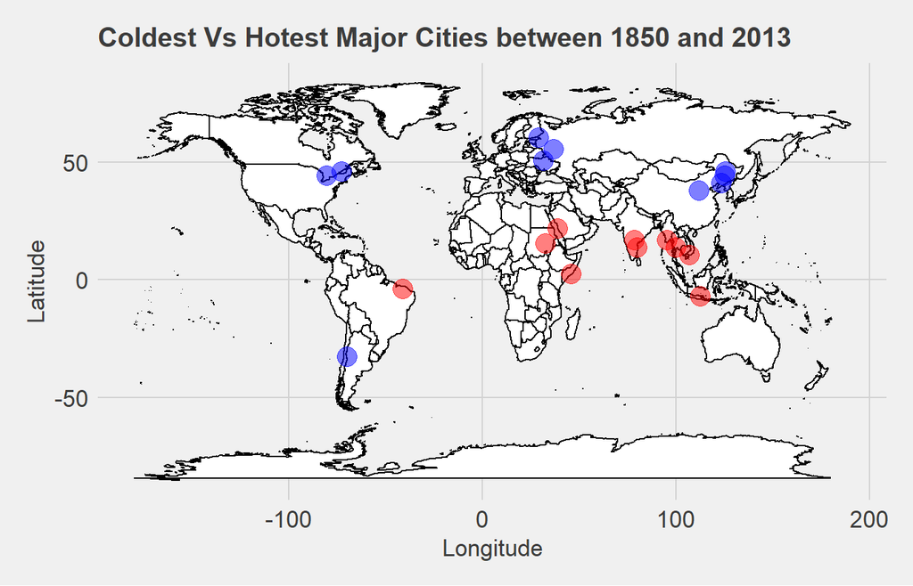

```r
# Converting Longitude and latitude in correct format in Top10coldest dataset
Top10Coldest$LAT <- as.numeric(gsub("N|E|S|W", "",Top10Coldest$Latitude))*ifelse(grepl("S",Top10Coldest$Latitude),-1,1)
Top10Coldest$LONG <- as.numeric(gsub("N|E|S|W", "", Top10Coldest$Longitude))*ifelse(grepl("W",Top10Coldest$Longitude),-1,1)
# Converting Longitude and latitude in correct format in Top10Hotest dataset
Top10Hotest$LAT <- as.numeric(gsub("N|E|S|W", "",Top10Hotest$Latitude))*ifelse(grepl("S",Top10Hotest$Latitude),-1,1)
Top10Hotest$LONG <- as.numeric(gsub("N|E|S|W", "", Top10Hotest$Longitude))*ifelse(grepl("W",Top10Hotest$Longitude),-1,1)
# Plottinig the coldest and hottest cities on world map
mapWorld <- borders("world", colour="black", fill="white") # create a layer of borders
mp <- ggplot() +   mapWorld
mp <- mp+ geom_point(aes(x=Top10Coldest$LONG, y=Top10Coldest$LAT) ,color="blue", size=5, alpha = .5) + ggtitle('Coldest Vs Hotest Major Cities between 1850 and 2013') + theme_fivethirtyeight() + xlab("Longitude") + ylab("Latitude") + theme(axis.title = element_text(size = 13), axis.text = element_text(size = 13)) + theme(plot.title = element_text(size = 15, lineheight=.8, face="bold"))
mp2 <- ggplot() +   mapWorld
mp2 <- mp+ geom_point(aes(x=Top10Hotest$LONG, y=Top10Hotest$LAT) ,color="red", size=5, alpha =.5)
mp2
```

## 2.9 Average Temperature by all Cities

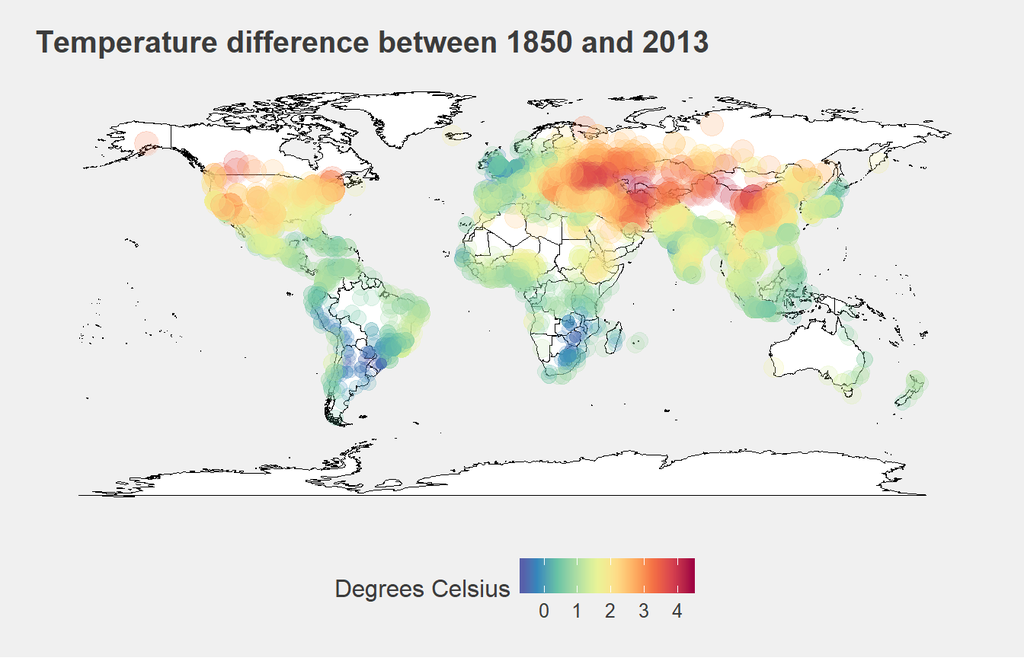

```r
# Grouping the dataset by Country and City
TempByAllCitiesSum <- TempByAllCities %>% group_by(Country, City) %>% select(AverageTemperature, City ,LAT, LONG, Country) %>% summarise(avgTemp_start = mean(AverageTemperature), long = mean(LONG), lat = mean(LAT))
# Focusing on year 2013
Year2013 <- TempByAllCities %>% filter(Year ==2013)
Year2013 <- Year2013 %>% group_by(Country,City) %>% select(AverageTemperature,City) %>% summarise(avgTemp_end = mean(AverageTemperature))
# Getting the final dataset
finalds <- merge(TempByAllCitiesSum,Year2013, by=c('Country','City'))
# Ploting the avg. temp difference on map
worldMap <- fortify(map_data("world"), region = "region")
m <- ggplot() + geom_map(data = worldMap, map = worldMap,aes(x = long, y = lat, map_id = region, group = group),fill = "white", color = "black", size = 0.1)
m + geom_point(data= finalds,aes(x=long, y=lat, size=avgTemp_end - avgTemp_start,color=avgTemp_end - avgTemp_start),alpha=.2) + theme_fivethirtyeight() + ggtitle('Temperature difference between 1850 and 2013') + theme(axis.text = element_blank(), panel.grid.major = element_blank(), panel.grid.minor = element_blank()) + labs(size = '') + scale_color_gradientn(name='Degrees Celsius',colors=rev(brewer.pal(10,'Spectral'))) + scale_size(guide = 'none') + theme(plot.title = element_text(size = 15, lineheight=.8, face="bold"))
```

## 2.10 Green House Gasses**

**Carbon Dioxide (CO2)**

Carbon Dioxide enters the atmosphere through burning fossil fuels (coal, natural gas, and oil), solid waste, trees and wood products, and also as a result of certain chemical reactions (e.g., manufacture of cement). Carbon Dioxide is removed from the atmosphere (or “sequestered”) when it is absorbed by plants as part of the biological carbon cycle.

**Methane (CH4)**

Methane is emitted during the production and transport of coal, natural gas, and oil. Methane emissions also result from livestock and other agricultural practices and by the decay of organic waste in municipal solid waste landfills.

**Nitrous Oxide (N2O)**

Nitrous Oxide is emitted during agricultural and industrial activities, as well as during combustion of fossil fuels and solid waste.

**Fluorinated Gases**

Hydrofluorocarbons, Perfluorocarbons, Sulfur Hexafluoride, and Nitrogen Trifluoride are synthetic, powerful greenhouse gases that are emitted from a variety of industrial processes. Fluorinated gases are sometimes used as substitutes for stratospheric ozone-depleting substances (e.g., chlorofluorocarbons, hydrochlorofluorocarbons, and halons). These gases are typically emitted in smaller quantities, but because they are potent greenhouse gases, they are sometimes referred to as High Global Warming Potential gases (“High GWP gases”).

## 2.11 Average Temperature In Atlanta

Since this is a city of my residence I am going to explore the trend of Average temperature between 1850 and 2013 in Atlanta (Georgia).

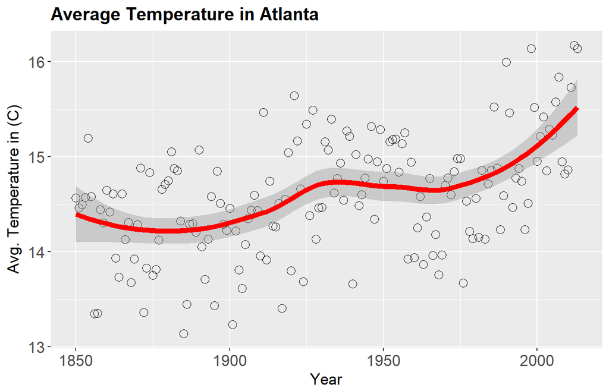

```r
# Extracting data for Atlanta and ploting on scatter plot
ATLTemp <- filter(TempByAllCities, City == "Atlanta")
ATLTempSum <- ATLTemp %>% group_by(Year) %>% summarise(AvgTemp = mean(AverageTemperature))
ggplot(ATLTempSum, aes(x=Year, y=AvgTemp)) + geom_point(shape=1, size = 3) + geom_smooth(method="loess", color = 'red', size = 2) + labs(title="Average Temperature in Atlanta ", x="Year", y="Avg. Temperature in (C)") +theme(axis.title = element_text(size = 13), axis.text = element_text(size = 13)) + theme(plot.title = element_text(size = 15, lineheight=.8, face="bold"))
```

# 3 Global Temperature Forecasting

For Global temperature forecasting I will use ARIMA model within R.

## 3.1 Data Examination

[output not shown]

```
##        dt             LandAverageTemperature
##  Min.   :1750-01-01   Min.   :-2.080
##  1st Qu.:1816-06-23   1st Qu.: 4.312
##  Median :1882-12-16   Median : 8.611
##  Mean   :1882-12-15   Mean   : 8.375
##  3rd Qu.:1949-06-08   3rd Qu.:12.548
##  Max.   :2015-12-01   Max.   :19.021
##                       NA's   :12
##  LandAverageTemperatureUncertainty LandMaxTemperature
##  Min.   :0.0340                    Length:3192
##  1st Qu.:0.1867                    Class :character
##  Median :0.3920                    Mode  :character
##  Mean   :0.9385
##  3rd Qu.:1.4192
##  Max.   :7.8800
##  NA's   :12
##  LandMaxTemperatureUncertainty LandMinTemperature
##  Length:3192                   Length:3192
##  Class :character              Class :character
##  Mode  :character              Mode  :character
##
##
##
##
##  LandMinTemperatureUncertainty LandAndOceanAverageTemperature
##  Length:3192                   Length:3192
##  Class :character              Class :character
##  Mode  :character              Mode  :character
##
##
##
##
##  LandAndOceanAverageTemperatureUncertainty
##  Length:3192
##  Class :character
##  Mode  :character
##
##
##
##
```

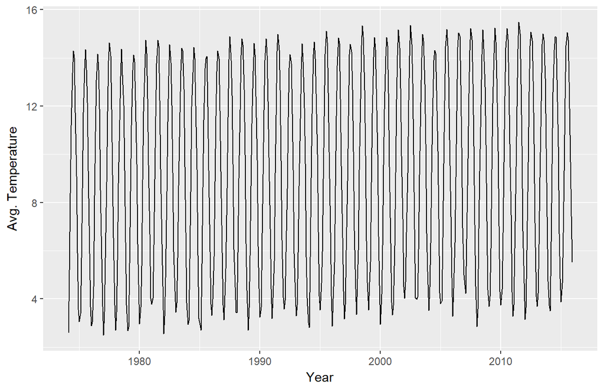

Removing outliers that could bias the model by skewing statistical summaries.

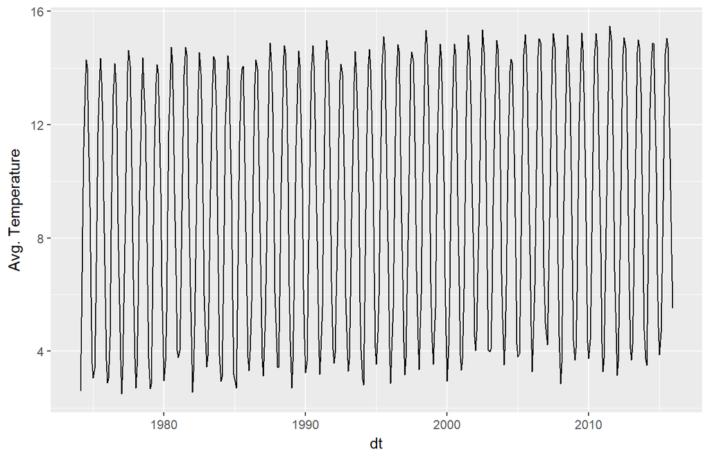

Plotting Monthly Moving Average

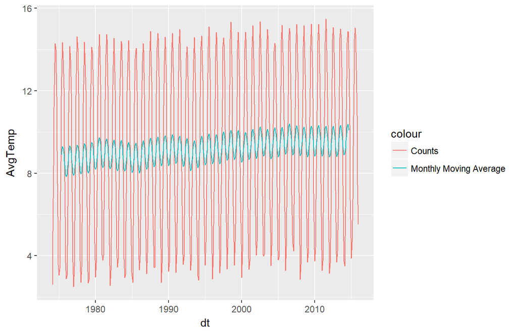

## 3.2 Decomposing the Data

In order to break the seasonality, trend or cycle if present in any data to make the forecasting accurate, we are going to use Decomposition of data.

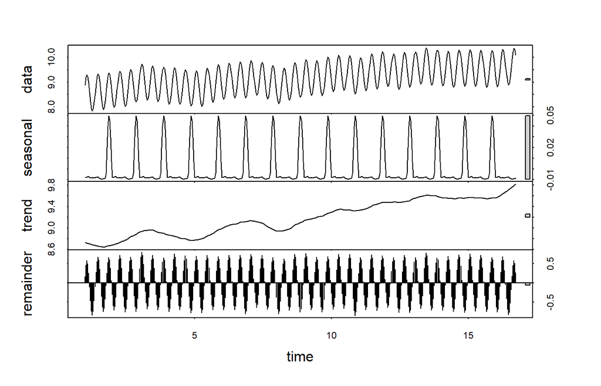

## 3.3 Stationarity

Fitting an ARIMA model requires the series to h ave its mean, variance, and autocovariance time invariant. This is means that series must be stationary.

```
##
##  Augmented Dickey-Fuller Test
##
## data:  AvgTemp_Ma
## Dickey-Fuller = -2.5816, Lag order = 7, p-value = 0.332
## alternative hypothesis: stationary
```

## 3.4 Autocorrelations and Choosing Model Order

Bellow, we have ACF and PACF diagrams which will be used to identify corelation between variable and its lags that is not explain by previous lags. We also going to use these diagrams to explore the order of paramtars for ARIMA model.

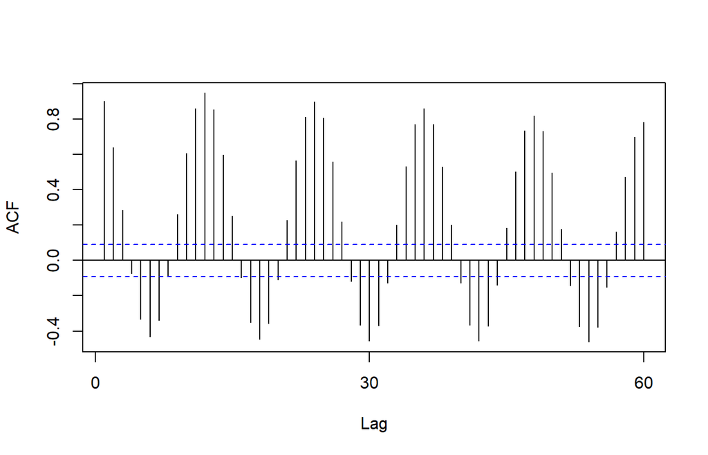

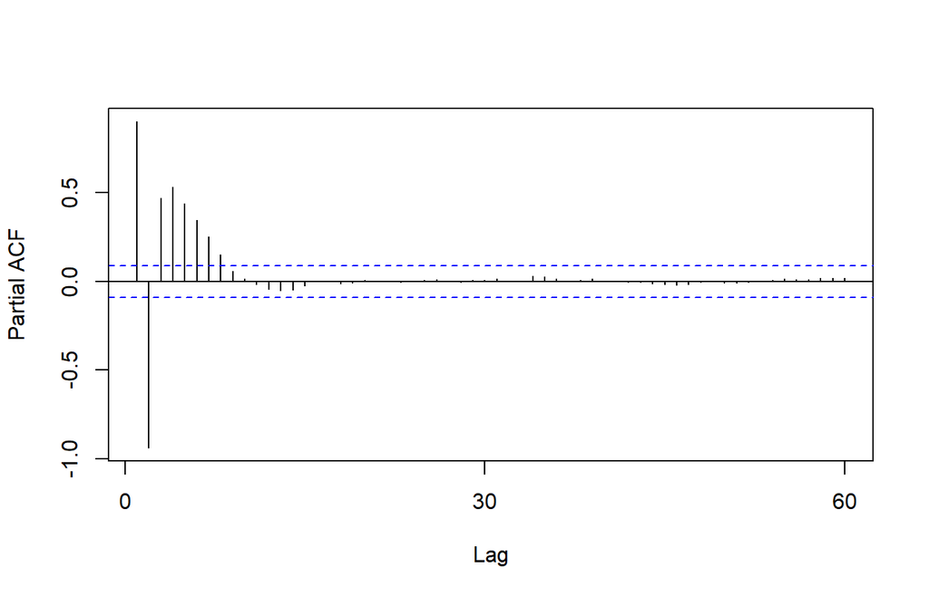

To remove the trend and coerce the data to stationarity we will perform data differencing which look at difference between the value of a time series at a certain point in time and its preceding value. Starting with the order of d = 1 and re-evaluate whether further differencing is needed.

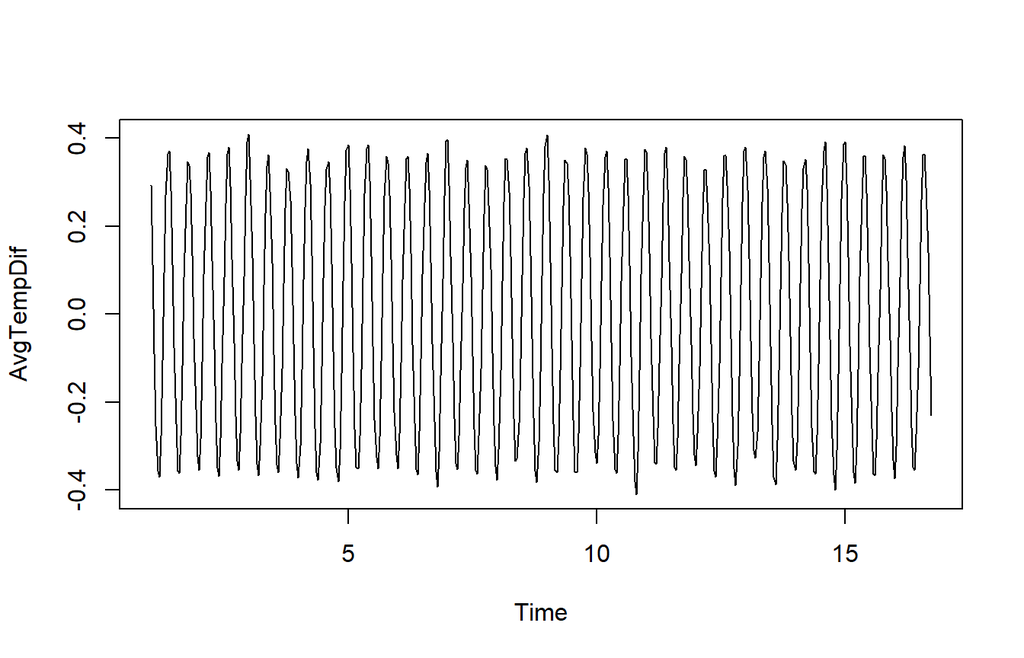

```
##
##  Augmented Dickey-Fuller Test
##
## data:  AvgTempDif
## Dickey-Fuller = -8.8921, Lag order = 7, p-value = 0.01
## alternative hypothesis: stationary
```

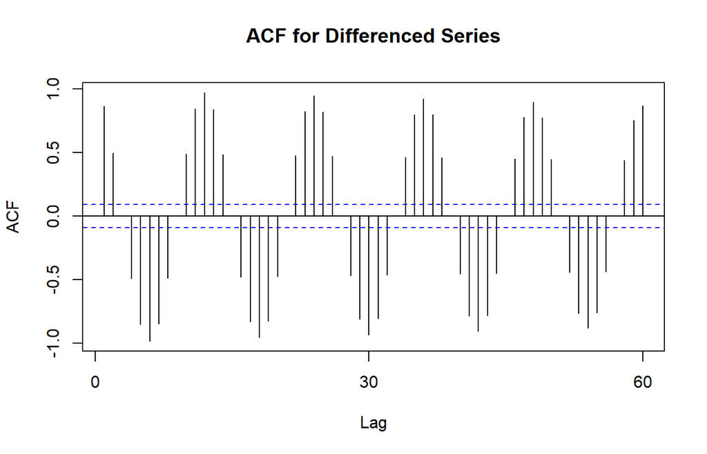

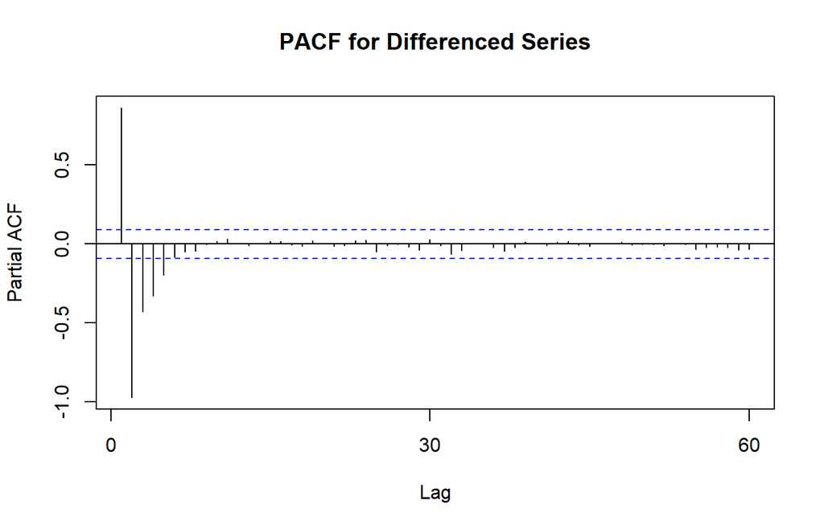

Differencing of d=1 did not perfrom well on this data set. I will perform more iterations with AR or MA models to identify the best model.

## 3.5 Fitting an ARIMA model

I am going to use afnction auto.arima() to automatically produce a set of optimal (p, d, q) parameters upon which will the fucntion will searches through the set to pick the right set that optimizes model.

```
## Series: deseasonal_AvgTemp
## ARIMA(1,1,5)
##
## Coefficients:
##          ar1     ma1     ma2     ma3     ma4     ma5
##       0.7314  1.9958  2.3137  2.1759  1.5150  0.5650
## s.e.  0.0346  0.0400  0.0663  0.0879  0.0876  0.0381
##
## sigma^2 estimated as 0.0007159:  log likelihood=1037.51
## AIC=-2061.01   AICc=-2060.77   BIC=-2031.91
```

[figure not shown]

Since auto.arima did not pefrom as expected i am going manualy to explore set of optimal paramters

## 3.6 Evaluate and Iterate

After several iteration of manual order with ARIMA, I identify that (11,1,14) parameters works the best to fit the model.

```
##
## Call:
## arima(x = deseasonal_AvgTemp, order = c(11, 1, 14))
##
## Coefficients:
##          ar1      ar2     ar3     ar4      ar5     ar6      ar7     ar8
##       0.5997  -0.1567  0.0268  0.5448  -0.4177  0.0998  -0.5745  0.3018
## s.e.     NaN      NaN     NaN     NaN      NaN     NaN      NaN     NaN
##          ar9    ar10    ar11     ma1      ma2     ma3     ma4      ma5
##       0.2303  0.2094  0.1364  0.6764  -0.0036  0.0752  -0.571  -0.3009
## s.e.     NaN  0.1665     NaN     NaN   0.0241     NaN     NaN      NaN
##           ma6     ma7     ma8      ma9     ma10     ma11     ma12    ma13
##       -0.0157  0.5797  0.4664  -0.2142  -0.4339  -0.5555  -0.4032  -0.262
## s.e.      NaN     NaN     NaN   0.0564      NaN   0.1562      NaN     NaN
##          ma14
##       -0.0369
## s.e.      NaN
##
## sigma^2 estimated as 7.293e-05:  log likelihood = 1562.89,  aic = -3073.78
```

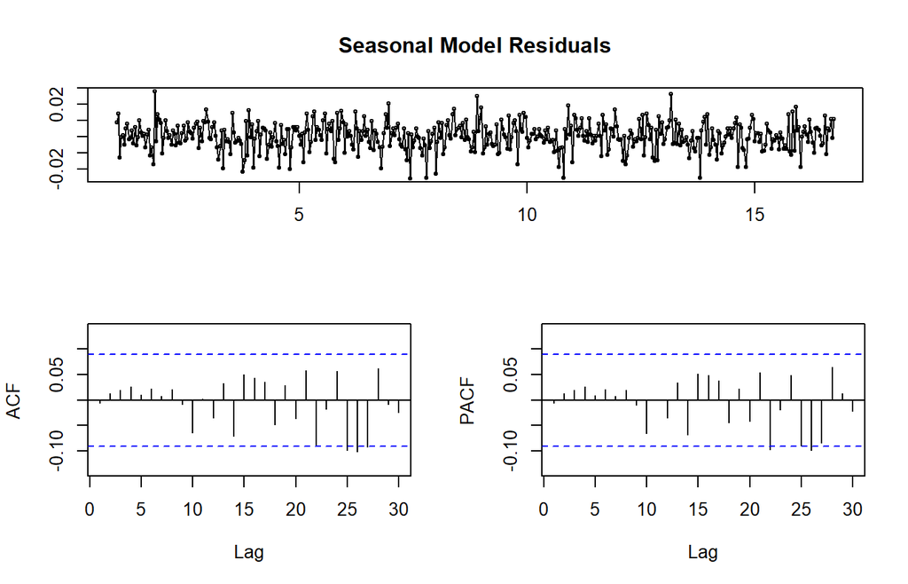

## 3.7 Forecasting

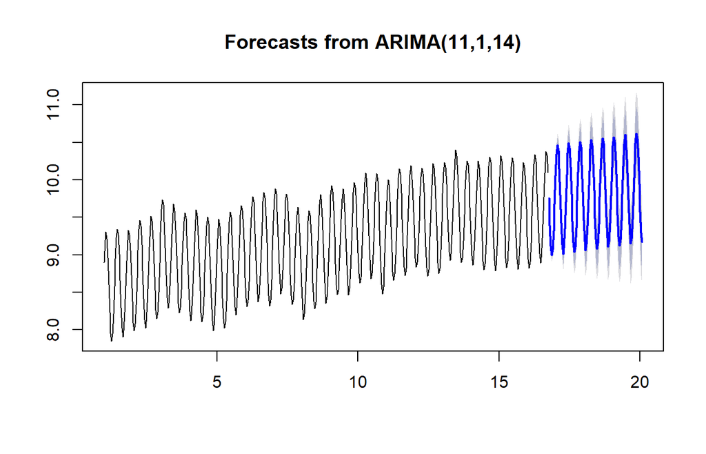

Displaying the Forecast model residuals

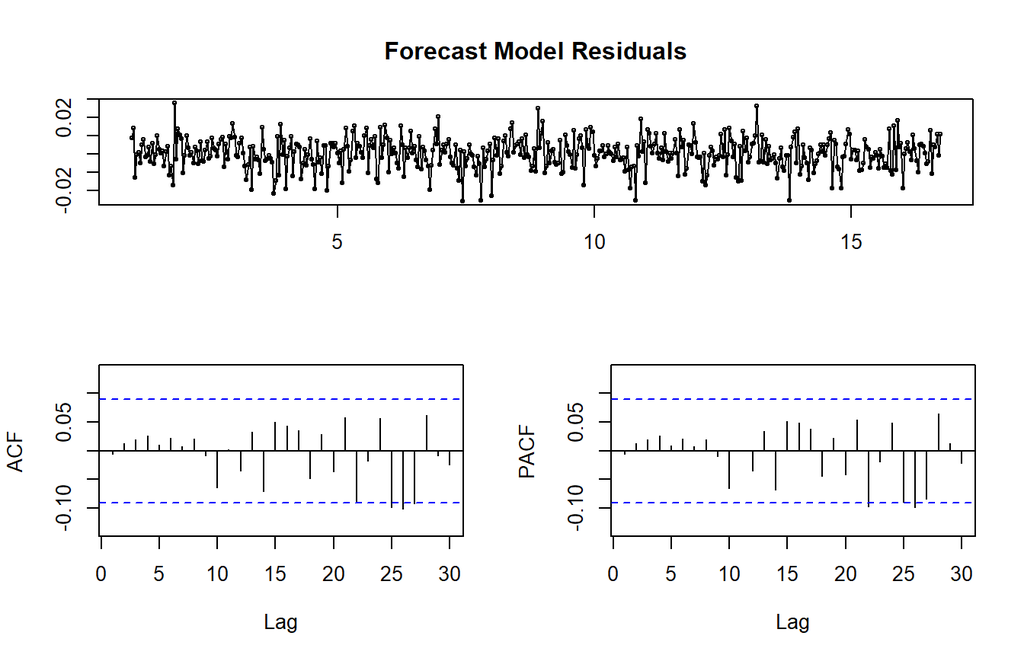

```
## [1] 100
```

```
## [1] 100
```

[output not shown]

[output cut: 86 more lines]

# 4 NASA`s findings on Rapid Climate Change***

**Rise of the Sea Level**

In past centruy global sea level rose ~ 8 inches. This rate nearly dobuled in last two decades.

**Rise of the Ocean Temperature**

The oceans have absorbed much of this increased heat, with the top 700 meters (about 2,300 feet) of ocean showing warming of 0.302 degrees Fahrenheit since 1969.

**Shrinking of Ice Sheets**

The Greenland and Antarctic ice sheets have decreased in mass. Data from NASA’s Gravity Recovery and Climate Experiment show Greenland lost 150 to 250 cubic kilometers (36 to 60 cubic miles) of ice per year between 2002 and 2006, while Antarctica lost about 152 cubic kilometers (36 cubic miles) of ice between 2002 and 2005.

**Glacial Retreat**

Glaciers are retreating almost everywhere around the world — including in the Alps, Himalayas, Andes, Rockies, Alaska and Africa.

**Ocean Acidification**

**Increase of the Global Temperature**

The Earth’s climate has changed throughout history. Just in the last 650,000 years there have been seven cycles of glacial advance and retreat, with the abrupt end of the last ice age about 7,000 years ago marking the beginning of the modern climate era — and of human civilization. Most of these climate changes are attributed to very small variations in Earth’s orbit that change the amount of solar energy our planet receives.

# 5 Conclusion

Based on conducted analysis, we can see that average temperature trend has highest growth in the past 3 decades. Since this research was not based on analysis of level of Green Gasses emition, I am unable to establish ratio of human influence on global warming versus natural event.  
While every event in the system in naturaly-logical cosenquence of the even that prior, as a civilization “Type 0” we might not be able to influnece Sun`s radiation spectrum but we can adjust our own behaviour.

# 6 References

** [EPA:] (https://www.epa.gov/ghgemissions/overview-greenhouse-gases)

***[NASA:] (https://climate.nasa.gov/evidence/)